# Time Series Homework Key: Chapter 1 Lesson 1

## Questions

### Question 1 (5 points)

What is something unusual or unique about you?

**Answer**

### Question 2 (5 points)

What do you hope to gain from this class?

**Answer**

EX: I’m looking to improve my ability to explain business and financial numbers using statistics. I hope this class gives me the skills and vocabulary to properly and correctly explain the statistical meanings behind business, financial, and/or economic data. I also hope that this course can help me use knowledge and skills related to my data science minor and apply them to my major. I’m also excited to expand my econometrics knowledge with this course.

**Tip for Exercise 3**

```r
# Load required R packages
if (!require("pacman")) install.packages("pacman")
pacman::p_load(tidyverse, lubridate)

# Set the random number seed
set.seed(100)

# Define the number of values to simulate
reps <- 4

# Create a data frame with a counter variable, t,
# and the simulated values, called x
df1 <- data.frame(t = 1:reps, x = runif(reps, min = 0, max = 1))
df1
```

```
  t          x
1 1 0.30776611
2 2 0.25767250
3 3 0.55232243
4 4 0.05638315
```

You can use inline R code as well. For example, the mean of the n=4 simulated x values is: 0.293536.

If you do not know how to use any command such as `rnorm` in R, you can type the name of the command after a question mark (e.g. `?rnorm`) in the console area, and the help file will appear on the right.

### Question 3 (10 points)

Use the `rnorm` command to simulate 100,000 normally-distributed random variables with a mean of 50 and a standard deviation of 10. Please do not list all the numbers. Instead, give a histogram of the data.*

**Answer**

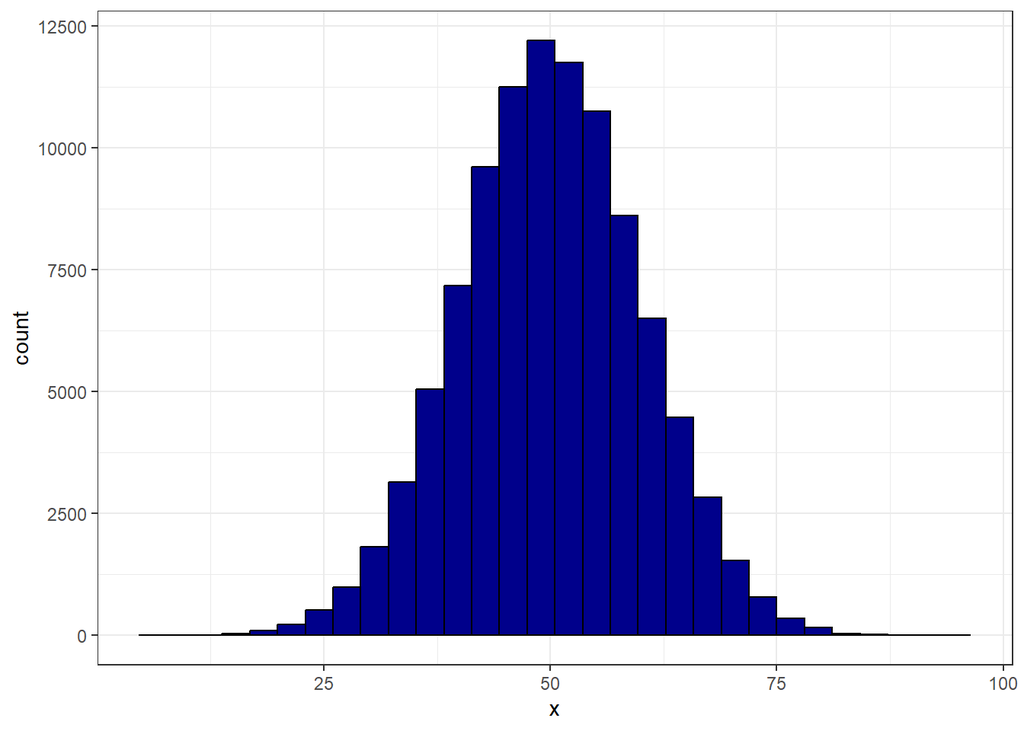

```r
q3df <- data.frame(x= rnorm(100000, mean = 50, sd = 10))

ggplot(q3df, aes(x=x))+
  geom_histogram(fill = "blue4", color = "black", bins = 30)+
  theme_bw()
```

### Question 4 (10 points)

Suppose your pulse was measured at the start of every hour today and the values are given in the data frame `pulse_df`.

```r
set.seed(123)
pulse_df <- data.frame(
  times = paste0(as.Date(substr(now(),1,10)), " ", c(0:23), ":00"),
  value = sample(70:100, size = 24, replace = TRUE)
)
```

We can convert a character representation of a date to a date-time object. The Lubridate package contains commands such as `mdy("12/31/2024")` which converts this value to: 2024-12-31. There are other variations of this command such as `dmy_hms("31/12/2024 15:16:47")` which gives us: 2024-12-31 15:16:47.

Use the command `ymd_hm()` to convert the `times` variable into a date-type variable. Then filter the four observations from noon to 3 PM (15:00).

There are many ways to accomplish this but here is one simple example:

```r
pulse_df$times <- ymd_hm(pulse_df$times) # convert times to date-type data
pulse_df_filtered <- pulse_df %>% filter(hour(times) >= 12 & hour(times) <= 15) # using the hour() function from lubridate we look at just the hour section of the 'times' variable and then filter to values between 12 and 15
```

Then, compute the mean of the observed value for these four times. Write your code in the R chunk below. Write an English sentence giving this mean and its interpretation in terms of your pulse rate.

**Answer**

```r
mean_pulse <-  mean(pulse_df_filtered$value)
mean_pulse
```

```
[1] 94
```

### Question 5 (5 points)

Do you have any concerns about your ability to succeed in this class? If so, please share them.

**Answer**

### Rubric

[output not shown]